# ———- General Overview of `incarceration_trends` and `jail_jurisdiction` ———-

For this assignment, I will be comparing data drawn from `incarceration_trends` and  
`jail_jurisdiction`, observing any differences between demographics such as race and gender. The information recorded in `incarceration_trends` is based on incarcerated populations & the surrounding areas on a county-level basis. `jail_jurisdiction` is based on incarcerated populations in local county jails.

Note: Jail refers to individuals who are held in lawful custody (i.e. have been convicted of a minor offense or are waiting to go on trial for their accusation) for a short period of time. The word jail implies that it is a smaller, local facility. Prison refers to individuals who have been convicted of more serious offenses and are sentenced to longer terms. Prison can also be referred to as “state prison” or “federal prison”, and refers to a larger facility of confinement than a county jail.

This table summarizes general information about each county:

```
##      county_name state urbanicity region           division commuting_zone
## 1 Autauga County    AL  small/mid  South East South Central             60
## 2 Baldwin County    AL  small/mid  South East South Central            254
## 3 Barbour County    AL      rural  South East South Central             20
## 4    Bibb County    AL   suburban  South East South Central             21
## 5  Blount County    AL   suburban  South East South Central             21
## 6 Bullock County    AL      rural  South East South Central             20
##   metro_area land_area
## 1      33860    594.45
## 2      19300   1589.82
## 3         NA    885.00
## 4      13820    622.46
## 5      13820    644.82
## 6         NA    622.81
```

# ———- Annual Total Incarcerations ———-

This section contains charts that show incarceration statistics for gender and race in jail and prison annually. The first columns include the numbers of the general population, which can be compared to the number of incarcerated individuals and provided demographics of that population.

Charts that compare gender (either for jail or prison) include total numbers of each gender and age categories. `jail_sortgender` contains more data than its `prison_sortgender` counterpart, as more data was provided by the Vera Institute. The data is divided up not only by gender but also by “juvenile” or “adulthood”.

`jail_sortgender`

```
## # A tibble: 6 x 15
##    year total_pop total_pop_15to64 females_15to64 males_15to64 total_incarcerat~
##   <int>     <int>            <int>          <int>        <int>             <dbl>
## 1  1970 203882263        125918857       64579692     61339165              54.9
## 2  1971 206708519        128475635       65755269     62720366              54.1
## 3  1972 209163959        131137282       66976150     64161132              54.2
## 4  1973 211237199        133590311       68170576     65419735              54.4
## 5  1974 213218350        135944506       69324623     66619883              54.6
## 6  1975 215335855        138290418       70487478     67802940              54.8
## # ... with 9 more variables: females_incarcerated <dbl>,
## #   males_incarcerated <dbl>, adult_females <dbl>, adult_males <dbl>,
## #   juvenile_females <dbl>, juvenile_males <dbl>, jail_deaths <dbl>,
## #   female_deaths <dbl>, male_deaths <dbl>
```

`prison_sortgender`

```
## # A tibble: 6 x 8
##    year total_pop total_pop_15to64 females_15to64 males_15to64 total_incarcerat~
##   <int>     <int>            <int>          <int>        <int>             <dbl>
## 1  1970 203882263        125918857       64579692     61339165              6635
## 2  1971 206708519        128475635       65755269     62720366              8607
## 3  1972 209163959        131137282       66976150     64161132              8914
## 4  1973 211237199        133590311       68170576     65419735              9764
## 5  1974 213218350        135944506       69324623     66619883             10661
## 6  1975 215335855        138290418       70487478     67802940             12040
## # ... with 2 more variables: females_incarcerated <dbl>,
## #   males_incarcerated <dbl>
```

Similarly, `jail_sortrace` and `prison_sortrace` compare numbers categorized by race. The total incarcerated population is grouped by race, providing a total population and individuals who are between the ages of 15 to 64. `prison_sortrace` was able to provide further information by specifying the gender of individuals along with race.

`jail_sortrace`

```
## # A tibble: 6 x 16
##    year total_pop total_pop_15to64 total_incarcerated white_totpop_15to64
##   <int>     <int>            <int>              <dbl>               <dbl>
## 1  1970 203882263        125918857               54.9                   0
## 2  1971 206708519        128475635               54.1                   0
## 3  1972 209163959        131137282               54.2                   0
## 4  1973 211237199        133590311               54.4                   0
## 5  1974 213218350        135944506               54.6                   0
## 6  1975 215335855        138290418               54.8                   0
## # ... with 11 more variables: white_incarcerated <dbl>,
## #   black_totpop_15to64 <dbl>, black_incarcerated <dbl>,
## #   latinx_totpop_15to64 <dbl>, latinx_incarcerated <dbl>,
## #   aapi_totpop_15to64 <dbl>, aapi_incarcerated <dbl>,
## #   native_totpop_15to64 <dbl>, native_incarcerated <dbl>,
## #   other_totpop_15to64 <dbl>, other_incarcerated <dbl>
```

`prison_sortrace`

```
## # A tibble: 6 x 28
##    year total_pop total_pop_15to64 total_incarcerated white_totpop_15to64
##   <int>     <int>            <int>              <dbl>               <dbl>
## 1  1970 203882263        125918857               6635                   0
## 2  1971 206708519        128475635               8607                   0
## 3  1972 209163959        131137282               8914                   0
## 4  1973 211237199        133590311               9764                   0
## 5  1974 213218350        135944506              10661                   0
## 6  1975 215335855        138290418              12040                   0
## # ... with 23 more variables: white_incarcerated <dbl>, white_females <dbl>,
## #   white_males <dbl>, black_totpop_15to64 <dbl>, black_incarcerated <dbl>,
## #   black_females <dbl>, black_males <dbl>, latinx_totpop_15to64 <dbl>,
## #   latinx_incarcerated <dbl>, latinx_females <dbl>, latinx_males <dbl>,
## #   aapi_totpop_15to64 <dbl>, aapi_incarcerated <dbl>, aapi_females <dbl>,
## #   aapi_males <dbl>, native_totpop_15to64 <dbl>, native_incarcerated <dbl>,
## #   native_females <dbl>, native_males <dbl>, other_totpop_15to64 <dbl>, ...
```

# ———- Comparing Jail Incarceration Statistics ———-

`jail_genderstats`

```
##   year    county_name state total_incarcerated females_incarcerated
## 1 1970 Autauga County    AL                 NA                   NA
## 2 1971 Autauga County    AL                 NA                   NA
## 3 1972 Autauga County    AL                 NA                   NA
## 4 1973 Autauga County    AL                 NA                   NA
## 5 1974 Autauga County    AL                 NA                   NA
## 6 1975 Autauga County    AL                 NA                   NA
##   males_incarcerated total_new_inmates total_pct_increase new_female_inmates
## 1                 NA                NA                 NA                 NA
## 2                 NA                NA                 NA                 NA
## 3                 NA                NA                 NA                 NA
## 4                 NA                NA                 NA                 NA
## 5                 NA                NA                 NA                 NA
## 6                 NA                NA                 NA                 NA
##   female_pct_increase new_male_inmates male_pct_increase total_discharged
## 1                  NA               NA                NA               NA
## 2                  NA               NA                NA               NA
## 3                  NA               NA                NA               NA
## 4                  NA               NA                NA               NA
## 5                  NA               NA                NA               NA
## 6                  NA               NA                NA               NA
```

`jail_racestats`

```
##   year    county_name state total_incarcerated total_new_inmates
## 1 1970 Autauga County    AL                 NA                NA
## 2 2018 Autauga County    AL                165               780
## 3 1970 Baldwin County    AL                 70                NA
## 4 2018 Baldwin County    AL                643             14557
## 5 1970 Barbour County    AL                 11                NA
## 6 2018 Barbour County    AL                111               780
##   total_pct_increase white_incarcerated white_rate black_incarcerated
## 1                 NA                 NA         NA                 NA
## 2             454.81                 76     281.17                 48
## 3             199.75                 NA         NA                 NA
## 4             477.31                461     411.23                165
## 5              83.27                 NA         NA                 NA
## 6             702.18                 82    1180.37                 10
##   black_rate latinx_incarcerated latinx_rate aapi_incarcerated aapi_rate
## 1         NA                  NA          NA                NA        NA
## 2     643.26                2.00      188.15                 0         0
## 3         NA                  NA          NA                NA        NA
## 4    1248.49               34.64      550.37                 1        49
## 5         NA                  NA          NA                NA        NA
## 6     124.13                8.00     1248.05                 0         0
##   native_incarcerated native_rate other_incarcerated total_discharged
## 1                  NA          NA                 NA               NA
## 2                0.83      542.48                  0             1040
## 3                  NA          NA                 NA               NA
## 4                0.00        0.00                  6            14370
## 5                  NA          NA                 NA               NA
## 6                3.66     5304.35                  0              260
```

# ———- Comparing Prison Incarceration Statistics ———-

`prison_genderadm` compares newly admitted inmates in state/federal prisons by gender over time. Grouped by year, the chart shows the sum of every new inmate in the country and the percent increase along with it. `prison_raceadm` compares newly admitted inmates in state/federal prisons by race over time. The chart takes into account total incarcerated numbers for each race, along with general admission numbers & rates and female/male admits & admission rates.

`prison_genderadm`

```
## # A tibble: 6 x 10
##    year total_incarcerated females_incarcera~ males_incarcerat~ total_new_inmat~
##   <int>              <dbl>              <dbl>             <dbl>            <dbl>
## 1  1970               6635                117              4802             2418
## 2  1971               8607                212              6055             5506
## 3  1972               8914                231              6345             5666
## 4  1973               9764                271              7261             6029
## 5  1974              10661                353              7990             6738
## 6  1975              12040                394              8685             7638
## # ... with 5 more variables: total_pct_increase <dbl>,
## #   new_female_inmates <dbl>, female_pct_increase <dbl>,
## #   new_male_inmates <dbl>, male_pct_increase <dbl>
```

`prison_raceadm`

```
## # A tibble: 6 x 33
##    year total_incarcerated total_new_inmates total_pct_increase white_incarcera~
##   <int>              <dbl>             <dbl>              <dbl>            <dbl>
## 1  1970               6635              2418             10934.             1666
## 2  1971               8607              5506             24547.             2315
## 3  1972               8914              5666             23851.             2275
## 4  1973               9764              6029             28353.             2601
## 5  1974              10661              6738             30021.             3033
## 6  1975              12040              7638             33857.             3158
## # ... with 28 more variables: white_adm <dbl>, white_admrate <dbl>,
## #   white_female_adm <dbl>, white_male_adm <dbl>, black_incarcerated <dbl>,
## #   black_adm <dbl>, black_admrate <dbl>, black_female_adm <dbl>,
## #   black_male_adm <dbl>, latinx_incarcerated <dbl>, latinx_adm <dbl>,
## #   latinx_admrate <dbl>, latinx_female_adm <dbl>, latinx_male_adm <dbl>,
## #   aapi_incarcerated <dbl>, aapi_adm <dbl>, aapi_admrate <dbl>,
## #   aapi_female_adm <dbl>, aapi_male_adm <dbl>, native_incarcerated <dbl>, ...
```

# ———- Trends Over Time Chart ———-

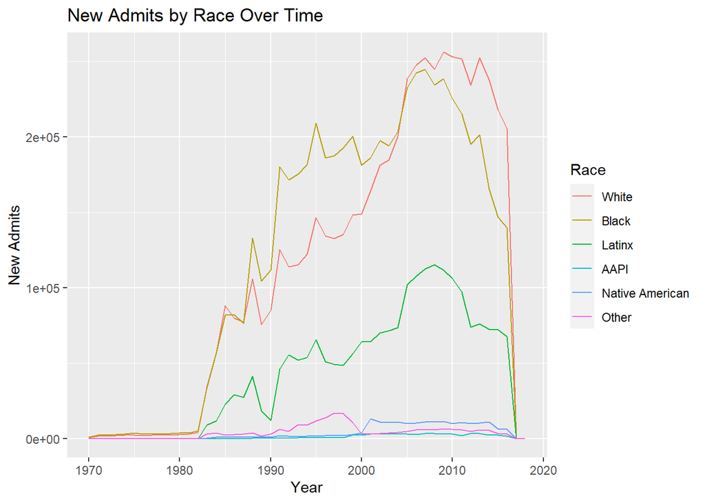

# ———- Variable Comparison Chart ———-

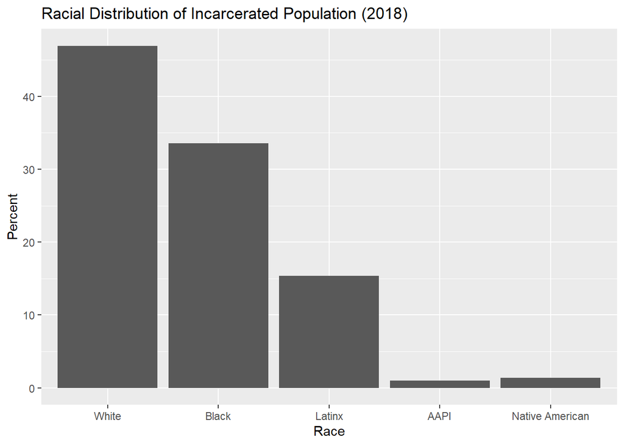

# ———- Map ———-

This map shows how races are distributed geographically from 2010. I picked this year instead of the most recent year of recorded data because the numbers between racial groups existed and were more comparable (frame of reference was the trends over time chart). I divided each map into racial groups to make comparing between them easy. Although numbers for AAPI and Native Americans are higher, they’re still relatively low compared to white, black, and latinx individuals. From the map, it appears that those incarcerations are more prevalent towards the south, especially in states like Texas and Florida. Higher numbers also showed up in California.

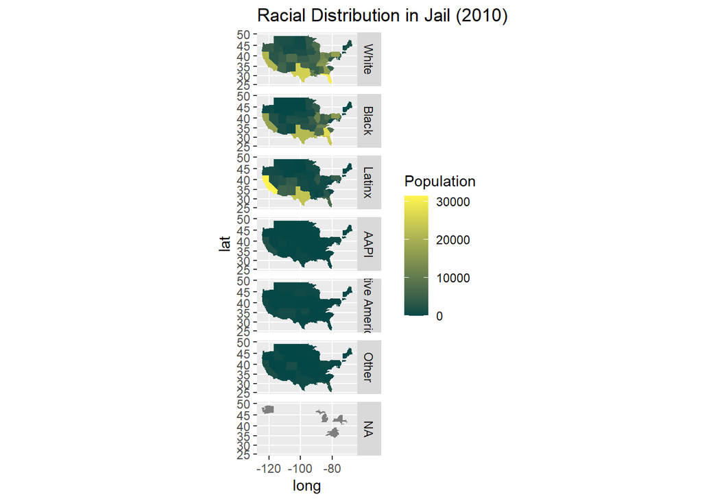